[figure not shown]

# Implied Volatility

**Kannan Singaravelu**

April, 2022

## Implied Volatility

Implied volatility (IV) is one of the most important parameter in options pricing. IV is determined by the current market price of option contracts on a particular underlying asset. IV is commonly represented as a percentage that indicates the annualized expected one standard deviation range for the underlying asset implied from the option prices.

IV $\sigma_{imp}$ is the volatility value $\sigma$ that makes the Black Scholes value of the option equal to the traded price of the option. In the Black-Scholes model, volatility is the only parameter that can't be directly observed. All other parameters can be determined through market data and this parameter is determined by a numerical optimization technique given the Black-Scholes model.

## Option class

We have created option class in the earlier Python Lab session. We will now append this class to include implied volatility calculation. We will also use `scipy` optimization toolbox to derive the roots of the non-linear equations.

Import required libraries

```python
# Data Manipulation
import pandas as pd
from numpy import *
import yfinance as yf
from datetime import date, timedelta

# Import BlackScholes
from src.blackscholes import BS

# Plotting
import cufflinks as cf
cf.set_config_file(offline=True)

# Ignore warnings
import warnings
warnings.filterwarnings('ignore')
```

## Implied Volatility Formulation

The Black–Scholes equation describes the price of the option over time as

$$ \frac{\partial V}{\partial t} + \frac 1{2}{\sigma^2 S^2} \frac{\partial^2 V}{\partial S^2} + r S \frac{\partial V}{\partial S} - rV = 0 $$

Solving the above equation, we know that the value of a call option for a non-dividend paying stock is:

$$C = SN(d_1) - Ke^{-rt}N(d_2) $$

and, the corresponding put option price is:

$$P = Ke^{-rt}N(-d_2) - SN(-d_1)$$

where,

$$d_1= \frac{1}{\sigma \sqrt{t}}\left[\ln{\left(\frac{S}{K}\right)} +{\left(r + \frac{\sigma^2}{2}\right)}t\right]$$

$$d_2= d_1 - \sigma \sqrt{t}$$

$$ N(x)=\frac{1}{\sqrt{2\pi}} \int_{-\infty}^{x} \mathrm e^{-\frac{1}{2}x^2} dx $$

$S$ is the spot price of the underlying asset  
$K$ is the strike price  
$r$ is the annualized continuous compounded risk free rate  
$\sigma$ is the volatility of returns of the underlying asset  
$t$ is time to maturity (expressed in years)  
$N(x)$ is the standard normal cumulative distribution

We can look at the call and put equation as a function of the volatility parameter $\sigma$. Finding implied volatility thus requires solving the nonlinear problem $f(x)=0$ where $x=\sigma$ given a starting estimate.

For call options we have, $$ f(x) = S N(d_1) - Ke^{-rt} N(d_2) - C $$

and for puts,

$$ f(x) = Ke^{-rt} N(-d_2) - S N(-d_1) - P $$

To solve the function when $f(x)=0$, numerical precedures like Bisection or Newton's method are employed.

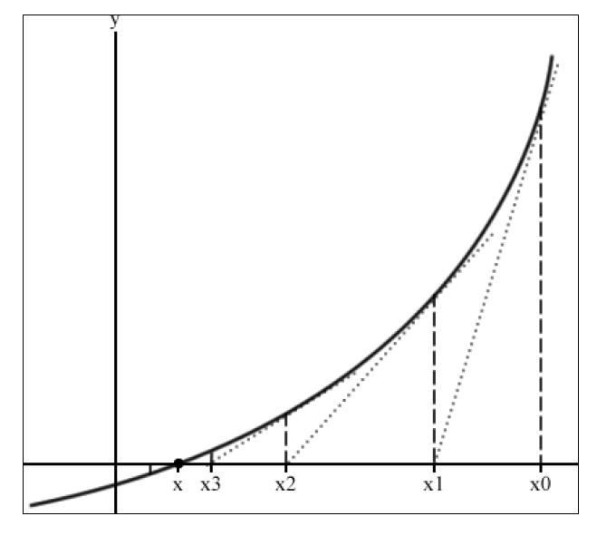

### Newton Method

The Newton-Raphson method uses an iterative procedure to solve for a root using informaiton about the derivative of a function. The first-order derivation $f'$ of the function $f$ represents the tangent line and the approximation to the next value of $x$ is given as

$$ x_1 = x - \frac{f(x)}{f'(x)} $$

The tangent line intersects the $x$ axis and $x_1$ that produces $y=0$. The iterative process is repeated until a maximum iterations are reached or the difference between $x_1$ and $x$ are within acceptable values.

This method requires to specify initial guess and expect the function to be differentiable. Newton approaches are extremely fast as the rate of convergence is quadractic. The downside to this approach is that it does not guarantee convergence if there are more than one root or when it reaches a local extremum.

```python
def newton_iv(className, spot, strike, rate, dte, volatility, callprice=None, putprice=None):

    x0 = 1 # initial guess
    h = 0.001
    tolerance = 1e-7
    epsilon = 1e-14                             # some kind of error or floor

    maxiter = 200

    if callprice:
        # f(x) = Black Scholes Call price - Market Price - defining the f(x) here
        f = lambda x: eval(className)(spot, strike, rate, dte, x).callPrice - callprice
    if putprice:
        f = lambda x: eval(className)(spot, strike, rate, dte, x).putPrice - putprice

    for i in range(maxiter):
        y = f(x0)
        yprime = (f(x0+h) - f(x0-h))/(2*h)      # central difference

        if abs(yprime)<epsilon:
            break                               # this is critial, because volatility cannot be negative
        x1 = x0 - y/yprime

        if (abs(x1-x0) <= tolerance*abs(x1)):
            break
        x0=x1

    return x1
```

```python
# newton iv
newton_iv('BS',100,100,0.02,1,0.2,callprice=8)
```

```
0.17657213831399154
```

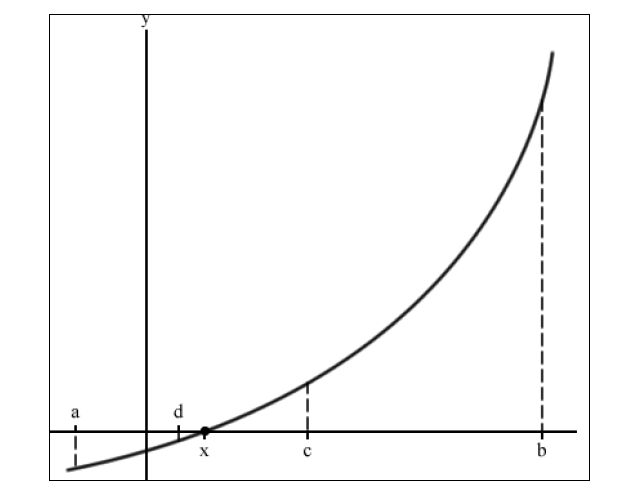

### Bisection Method

The bisection method is considered to be one of the simplest and robust root finding algorithm.

Suppose, we know the two points of an interval $a$ and $b$, where $a<b$ and $f(a)<0$ and $f(b)>0$ lie along the continuous function and the mid-point of this interval $c = \frac{a+b}{2}$, then we can evaluate the value as $f(c)$.

Iteratively, we replace $c$ as either $a$ or $b$, thereby shortening the interval to find the root. If $f(c) = 0$ or within acceptable value, we have a root. Bisection methods are stable and guarantee to converge. As it does not require knowledge of the derivative, it takes more computational time.

```python
# Bisection Method
def bisection_iv(className, spot, strike, rate, dte, volatility, callprice=None, putprice=None, high=500.0, low=0.0):

    # this is market price
    if callprice:
        price = callprice
    if putprice and not callprice:
        price = putprice

    tolerance = 1e-7

    for i in range(1000):
        mid = (high + low) / 2 # c= (a+b)/2
        if mid < tolerance:
            mid = tolerance

        if callprice:
            estimate = eval(className)(spot, strike, rate, dte, mid).callPrice # Blackscholes price
        if putprice:
            estimate = eval(className)(spot, strike, rate, dte, mid).putPrice

        if round(estimate,6) == price:
            break
        elif estimate > price:
            high = mid # b = c
        elif estimate < price:
            low = mid # a = c

    return mid
```

```python
# bisection iv
bisection_iv('BS',100,100,0.02,1,0.2,callprice=8)
```

```
0.17657213902566582
```

## SPX Option

Let's now retrieve SPX option price from Yahoo Finance using `yfinance` library and manipulated the dataframe using the above Black Scholes option pricing model that we created.

https://finance.yahoo.com/quote/^SPX/options?date=1656547200

```python
# Create a ticker object
spx = yf.Ticker('^SPX')
```

```python
# Get Expiry dates
expiry_dates = sorted(spx.options)
expiry_dates[:15]
```

```
['2022-04-06',
 '2022-04-08',
 '2022-04-11',
 '2022-04-13',
 '2022-04-14',
 '2022-04-18',
 '2022-04-20',
 '2022-04-22',
 '2022-04-25',
 '2022-04-27',
 '2022-04-29',
 '2022-05-02',
 '2022-05-06',
 '2022-05-13',
 '2022-05-20']
```

```python
# retrieve from yahoo finance
spx_call = spx.option_chain().calls
spx_puts = spx.option_chain().puts

# save locally
# spx_call.to_csv('data/spx_call.csv')
# spx_puts.to_csv('data/spx_puts.csv')
```

```python
# Filter call option for June 2022 Expiry
jun = spx.option_chain('2022-06-30')

# Filter calls for strike above 4535
jun = jun.calls[jun.calls['strike']>4535]
jun.set_index('strike', inplace=True)

# Check the filtered output
jun.iloc[:,:11].head()
```

| strike | contractSymbol | lastTradeDate | lastPrice | bid | ask | change | percentChange | volume | openInterest | impliedVolatility | inTheMoney |
| --- | --- | --- | --- | --- | --- | --- | --- | --- | --- | --- | --- |
| 4540.0 | SPXW220630C04540000 | 2022-04-05 17:15:46 | 160.80 | 165.8 | 166.4 | -7.000000 | -4.171633 | 0.0 | 54 | 0.179103 | True |
| 4545.0 | SPXW220630C04545000 | 2022-04-04 18:44:24 | 171.60 | 162.6 | 163.2 | 0.000000 | 0.000000 | 24.0 | 92 | 0.178286 | True |
| 4550.0 | SPXW220630C04550000 | 2022-04-05 16:22:36 | 155.70 | 159.4 | 160.1 | -13.000000 | -7.705987 | 9.0 | 870 | 0.177556 | True |
| 4555.0 | SPXW220630C04555000 | 2022-04-05 15:28:49 | 159.85 | 156.1 | 156.8 | -23.569992 | -12.850286 | 1.0 | 22 | 0.176571 | True |
| 4560.0 | SPXW220630C04560000 | 2022-04-04 15:57:46 | 159.40 | 153.1 | 153.7 | 0.000000 | 0.000000 | 6.0 | 48 | 0.175786 | False |

```python
jun[['bid', 'impliedVolatility']][:4750].iplot(secondary_y='impliedVolatility', mode='lines+markers', size=6,
                                              xTitle='Strike Price', title='Option Call Price Vs Implied Volatility')
```

[interactive chart not shown]

## IV Skew

#### User Defined Function

```python
def ivskew(spot, rate, value_date, expiry, dataframe):

    dte = (pd.Timestamp(expiry)-pd.Timestamp(value_date))/timedelta(365)

    df = dataframe[['bid', 'ask']]
    df['mid'] = 0.5 * (df['bid']+df['ask'])
    df['strike'] = df.index
    df['IV'] = 0.

    for i in range(len(df)):
        df['IV'].iloc[i] = 100*BS(spot,
                                df.strike.iloc[i],
                                rate, dte, 0.2,
                                callprice = df.mid.iloc[i]).impvol

    return df['IV']
```

```python
# call the iv skew function
ivskew(4535, 0.007,'2022-04-06', '2022-06-30', jun)
```

```
strike
4540.0    18.898834
4545.0    18.807668
4550.0    18.719556
4555.0    18.611550
4560.0    18.529436
            ...
6200.0    19.779193
6300.0    20.000000
6400.0    20.987428
6500.0    21.856291
6700.0    20.000000
Name: IV, Length: 145, dtype: float64
```

```python
# Set expiry list
expiry_list = ['2022-04-11' , '2022-04-13']

# Initialise empty dataframe
call_close = pd.DataFrame()
call_vols = pd.DataFrame()

for expiry in expiry_list:

    sub_set = spx.option_chain(expiry).calls
    sub_set = sub_set[(sub_set.strike>4535) & (sub_set.strike<4750)]
    sub_set.set_index('strike', inplace=True)

    call_close[expiry] = sub_set['ask']
    call_vols[expiry] = ivskew(4535, 0.007, '2022-04-06', expiry, sub_set)
```

```python
# Verify Call IV
# call_vols.index = around(call_vols.index/390,3)
call_vols.iloc[:10]
```

| strike | 2022-04-11 | 2022-04-13 |
| --- | --- | --- |
| 4540.0 | 21.239085 | 20.931167 |
| 4545.0 | 20.789348 | 20.517946 |
| 4550.0 | 20.412743 | 20.633420 |
| 4555.0 | 20.108057 | 20.094635 |
| 4560.0 | 19.778326 | 19.781865 |
| 4565.0 | 19.494385 | 19.493745 |
| 4570.0 | 19.156886 | 19.188294 |
| 4575.0 | 18.913610 | 19.010423 |
| 4580.0 | 18.587321 | 18.751767 |
| 4585.0 | 18.250422 | 18.515943 |

## Visualize

```python
call_close.iplot(mode='lines+markers', symbol=['circle-dot', 'square'], size=6,
                 title='Option Call Price', xTitle='strike price')
```

[interactive chart not shown]

```python
call_vols[:4750].iplot(mode='lines+markers', symbol=['circle-dot', 'square'], size=6,
                 title='Expiry-wise IV Skew', xTitle='strike price')
```

[interactive chart not shown]

# References

- [Python Resources](https://urldefense.com/v3/__https://github.com/kannansingaravelu/PythonResources__;!!KGvANbslH1YjwA!4OXjilW4lCPc922nOumHnliZU1865wkYas3W5oYhDN9JQQ_ccbWKZ-1a4O3DIuOyNckhP0KW8XSyTyeys4ql5-BeZftUuYU_BI8A5g$)

[Kannan Singaravelu](https://urldefense.com/v3/__http://twitter.com/kannansi__;!!KGvANbslH1YjwA!4OXjilW4lCPc922nOumHnliZU1865wkYas3W5oYhDN9JQQ_ccbWKZ-1a4O3DIuOyNckhP0KW8XSyTyeys4ql5-BeZftUuYULMe_4jg$) | [GitHub](https://urldefense.com/v3/__https://github.com/kannansingaravelu__;!!KGvANbslH1YjwA!4OXjilW4lCPc922nOumHnliZU1865wkYas3W5oYhDN9JQQ_ccbWKZ-1a4O3DIuOyNckhP0KW8XSyTyeys4ql5-BeZftUuYVEkK84UA$)

April, 2022